# Election Contribution Data Analysis

Aparna Yerramilli

May 1, 2017

# This report explores 2008 election contributions data for Washington(WA) state.

### Review data structure

```
## 'data.frame':    147149 obs. of  18 variables:
##  $ cmte_id          : Factor w/ 20 levels "C00420224","C00423202",..: 16 16 16 19 19 16 16 18 18 18 ...
##  $ cand_id          : Factor w/ 19 levels "P00003186","P00003251",..: 19 19 19 1 1 19 19 8 8 8 ...
##  $ cand_nm          : Factor w/ 19 levels "Biden, Joseph R Jr",..: 10 10 10 19 19 10 10 15 15 15 ...
##  $ contbr_nm        : Factor w/ 40739 levels "AADSEN, TELE",..: 30315 11665 18382 8033 8033 27777 27785 13860 30793 5522 ...
##  $ contbr_city      : Factor w/ 572 levels "`COLVILLE","9 MILE FALLS",..: 277 464 235 389 389 146 146 413 498 42 ...
##  $ contbr_st        : Factor w/ 1 level "WA": 1 1 1 1 1 1 1 1 1 1 ...
##  $ contbr_zip       : Factor w/ 30065 levels "","00000","000098178",..: 3948 22689 29582 21903 21903 20969 20969 5939 23483 1223 ...
##  $ contbr_employer  : Factor w/ 13968 levels "","'NONE'","-",..: 9633 10415 1 2888 2888 3336 12326 312 7785 7785 ...
##  $ contbr_occupation: Factor w/ 8560 levels "","-","(IT) SYSTEM PROGRAMMER",..: 6432 6396 6558 5308 5308 7672 3666 6647 4965 3480 ...
##  $ contb_receipt_amt: num  100 100 500 100 200 500 500 51 200 100 ...
##  $ contb_receipt_dt : Factor w/ 740 levels "01-APR-07","01-APR-08",..: 580 721 220 536 678 262 262 732 225 494 ...
##  $ receipt_desc     : Factor w/ 44 levels "","* EARMARKED CONTRIBUTION: SEE BELOW REDESIGNATION",..: 1 1 1 1 1 1 1 1 1 1 ...
##  $ memo_cd          : Factor w/ 2 levels "","X": 1 1 1 1 1 1 1 1 1 1 ...
##  $ memo_text        : Factor w/ 95 levels "","*","* EARMARKED CONTRIBUTION: SEE BELOW",..: 1 1 1 1 1 1 1 1 1 1 ...
##  $ form_tp          : Factor w/ 3 levels "SA17A","SA18",..: 1 1 1 1 1 1 1 1 1 1 ...
##  $ file_num         : int  326973 330012 330012 313015 313015 326973 326973 336959 336959 336959 ...
##  $ tran_id          : Factor w/ 146802 levels "0232549","0232852",..: 138444 138749 136955 129627 135991 137682 137681 1494 1342 1651 ...
##  $ election_tp      : Factor w/ 3 levels "","G2008","P2008": 3 3 3 3 3 3 3 3 3 3 ...
```

### Summary of the data structure

```
##       cmte_id            cand_id                          cand_nm
##  C00431445:108444   P80003338:108444   Obama, Barack          :108444
##  C00431569: 14734   P00003392: 14734   Clinton, Hillary Rodham: 14734
##  C00430470:  9159   P80002801: 10793   McCain, John S         : 10793
##  C00431205:  3824   P40002347:  3824   Edwards, John          :  3824
##  C00432914:  3360   P80000748:  3360   Paul, Ron              :  3360
##  C00431171:  2042   P80003353:  2042   Romney, Mitt           :  2042
##  (Other)  :  5586   (Other)  :  3952   (Other)                :  3952
##            contbr_nm         contbr_city    contbr_st     contbr_zip
##  WISE, JIM      :   139   SEATTLE  :48833   WA:147149   98103  :   376
##  SHUSHAN, DENISE:   125   BELLEVUE : 5299               98112  :   343
##  LOVE, PHOEBE   :   115   TACOMA   : 3854               98115  :   282
##  GEARY, PHILLIP :   105   VANCOUVER: 3730               98102  :   267
##  WHITE, SUSAN   :   105   OLYMPIA  : 3570               98052  :   264
##  VASERENO, KIM  :    95   SPOKANE  : 3369               98110  :   253
##  (Other)        :146465   (Other)  :78494               (Other):145364
##       contbr_employer     contbr_occupation contb_receipt_amt
##  NOT EMPLOYED :29999   RETIRED     :31054   Min.   :-6900.00
##  SELF EMPLOYED:18200   NOT EMPLOYED: 5152   1st Qu.:   30.00
##  RETIRED      : 5645   ATTORNEY    : 5046   Median :   89.03
##               : 4501   PHYSICIAN   : 3052   Mean   :  172.66
##  MICROSOFT    : 3030   HOMEMAKER   : 2772   3rd Qu.:  150.00
##  (Other)      :85333   (Other)     :99795   Max.   : 9200.00
##  NA's         :  441   NA's        :  278
##   contb_receipt_dt                                 receipt_desc
##  30-SEP-08:  3424                                        :139469
##  16-OCT-08:  3162   REATTRIBUTION/REDESIGNATION REQUESTED:  1690
##  24-OCT-08:  2286   REDESIGNATION FROM PRIMARY           :  1348
##  31-OCT-08:  2045   REDESIGNATION FROM                   :  1280
##  04-SEP-08:  2003   REDESIGNATION TO                     :  1280
##  30-APR-08:  1889   Refund                               :   810
##  (Other)  :132340   (Other)                              :  1272
##  memo_cd                                    memo_text       form_tp
##   :137975                                        :131528   SA17A:137988
##  X:  9174   OVF TRANSFER                         :  6759   SA18 :  8351
##             REATTRIBUTION/REDESIGNATION REQUESTED:  1690   SB28A:   810
##             REDESIGNATION FROM PRIMARY           :  1348
##             ORIGINAL TRANSACTION                 :  1313
##             REDESIGNATION FROM                   :  1280
##             (Other)                              :  3231
##     file_num          tran_id       election_tp
##  Min.   :288757   SB28A.55:     3        :   24
##  1st Qu.:360401   0284887 :     2   G2008:53954
##  Median :753769   0294867 :     2   P2008:93171
##  Mean   :616039   0298238 :     2
##  3rd Qu.:753821   0300006 :     2
##  Max.   :877004   0303413 :     2
##                   (Other) :147136
```

### Remove the data not needed for analysis

- Remove refunds and reattributions to avoid double counting
- Subset columns 3 through 11 for analysis.

### Review the data structure

```
## 'data.frame':    135692 obs. of  9 variables:
##  $ cand_nm          : Factor w/ 19 levels "Biden, Joseph R Jr",..: 10 10 10 19 19 10 10 15 15 15 ...
##  $ contbr_nm        : Factor w/ 40739 levels "AADSEN, TELE",..: 30315 11665 18382 8033 8033 27777 27785 13860 30793 5522 ...
##  $ contbr_city      : Factor w/ 572 levels "`COLVILLE","9 MILE FALLS",..: 277 464 235 389 389 146 146 413 498 42 ...
##  $ contbr_st        : Factor w/ 1 level "WA": 1 1 1 1 1 1 1 1 1 1 ...
##  $ contbr_zip       : Factor w/ 30065 levels "","00000","000098178",..: 3948 22689 29582 21903 21903 20969 20969 5939 23483 1223 ...
##  $ contbr_employer  : Factor w/ 13968 levels "","'NONE'","-",..: 9633 10415 1 2888 2888 3336 12326 312 7785 7785 ...
##  $ contbr_occupation: Factor w/ 8560 levels "","-","(IT) SYSTEM PROGRAMMER",..: 6432 6396 6558 5308 5308 7672 3666 6647 4965 3480 ...
##  $ contb_receipt_amt: num  100 100 500 100 200 500 500 51 200 100 ...
##  $ contb_receipt_dt : Factor w/ 740 levels "01-APR-07","01-APR-08",..: 580 721 220 536 678 262 262 732 225 494 ...
```

### Summary of the dataset and explore candidates

```
##                     cand_nm                contbr_nm
##  Obama, Barack          :99974   WISE, JIM      :   104
##  Clinton, Hillary Rodham:14514   VASERENO, KIM  :    95
##  McCain, John S         : 8460   LOVE, PHOEBE   :    91
##  Edwards, John          : 3768   SHUSHAN, DENISE:    91
##  Paul, Ron              : 3252   WHITE, SUSAN   :    83
##  Romney, Mitt           : 1916   GIROLAMI, TONY :    77
##  (Other)                : 3808   (Other)        :135151
##      contbr_city    contbr_st     contbr_zip          contbr_employer
##  SEATTLE   :44558   WA:135692   98103  :   359   NOT EMPLOYED :28501
##  BELLEVUE  : 4756               98112  :   318   SELF EMPLOYED:16856
##  TACOMA    : 3617               98115  :   262   RETIRED      : 5163
##  VANCOUVER : 3455               98052  :   256                : 3081
##  OLYMPIA   : 3350               98102  :   250   MICROSOFT    : 2773
##  BELLINGHAM: 3084               98110  :   232   (Other)      :78920
##  (Other)   :72872               (Other):134015   NA's         :  398
##     contbr_occupation contb_receipt_amt  contb_receipt_dt
##  RETIRED     :28962   Min.   :   0.5    04-SEP-08:  2001
##  NOT EMPLOYED: 4838   1st Qu.:  30.0    30-SEP-08:  1919
##  ATTORNEY    : 4402   Median : 100.0    31-OCT-08:  1897
##  PHYSICIAN   : 2768   Mean   : 178.3    30-APR-08:  1866
##  HOMEMAKER   : 2513   3rd Qu.: 150.0    23-OCT-08:  1771
##  (Other)     :91953   Max.   :9200.0    16-OCT-08:  1706
##  NA's        :  256                     (Other)  :124532
```

```
##
##      Biden, Joseph R Jr  Brownback, Samuel Dale Clinton, Hillary Rodham
##                     114                     119                   14514
##             Cox, John H     Dodd, Christopher J           Edwards, John
##                       3                     100                    3768
##    Gilmore, James S III     Giuliani, Rudolph W            Gravel, Mike
##                       5                     362                      25
##          Huckabee, Mike          Hunter, Duncan      Kucinich, Dennis J
##                     826                      75                     640
##          McCain, John S           Obama, Barack               Paul, Ron
##                    8460                   99974                    3252
##        Richardson, Bill            Romney, Mitt Tancredo, Thomas Gerald
##                     677                    1916                     252
##   Thompson, Fred Dalton
##                     610
```

### Remove candidates who have received less than 500 contributions

### Clean up zipcode(contbr_zip) column by keeping only first five characters and display the top 6 zipcodes where the most number of donations came from.

```
##
## 98115 98103 98112 98122 98110 98105
##  4308  3962  3645  2745  2677  2647
```

### Change the following Column types

– Change candidate name(cand_nm) from factor to character – change zipcode(contbr_zip) from factor to numeric – change contribution date (contb_receipt_dt) from factor to date

### Add two additional columns

– party column based on the candidate name and gender column based on the contributor’s first name

### Verify the final data structure

```
## 'data.frame':    130260 obs. of  12 variables:
##  $ FirstName        : chr  "AARON" "AARON" "AARON" "AARON" ...
##  $ cand_nm          : Factor w/ 10 levels "Clinton, Hillary Rodham",..: 6 6 6 6 7 6 6 6 6 6 ...
##  $ LastName         : chr  "ROBERTS" "RITOCH" "HOROWITZ" "RANDALL" ...
##  $ contbr_city      : Factor w/ 542 levels "`COLVILLE","9 MILE FALLS",..: 424 97 160 293 424 299 424 97 97 424 ...
##  $ contbr_st        : Factor w/ 1 level "WA": 1 1 1 1 1 1 1 1 1 1 ...
##  $ contbr_zip       : num  98118 98922 98203 98272 98102 ...
##  $ contbr_employer  : Factor w/ 13349 levels "","'NONE'","-",..: 10826 10915 11995 1296 6915 4616 2091 10915 10915 10826 ...
##  $ contbr_occupation: Factor w/ 8276 levels "","-","(IT) SYSTEM PROGRAMMER",..: 6637 6273 5642 4271 6902 3864 2863 6273 6273 6637 ...
##  $ contb_receipt_amt: num  100 50 100 250 250 50 250 16 47 30 ...
##  $ contb_receipt_dt : Date, format: "2008-09-05" "2008-10-01" ...
##  $ party            : Factor w/ 2 levels "D","R": 1 1 1 1 2 1 1 1 1 1 ...
##  $ gender           : Factor w/ 2 levels "female","male": 2 2 2 2 2 2 2 2 2 2 ...
```

### Summary of the variables and total $ contributed by gender:

```
##   FirstName                            cand_nm        LastName
##  Length:130260      Obama, Barack          :96902   Length:130260
##  Class :character   Clinton, Hillary Rodham:13853   Class :character
##  Mode  :character   McCain, John S         : 8143   Mode  :character
##                     Edwards, John          : 3699
##                     Paul, Ron              : 3137
##                     Romney, Mitt           : 1856
##                     (Other)                : 2670
##      contbr_city    contbr_st     contbr_zip         contbr_employer
##  SEATTLE   :42997   WA:130260   Min.   :    0   NOT EMPLOYED :27732
##  BELLEVUE  : 4434               1st Qu.:98102   SELF EMPLOYED:16379
##  TACOMA    : 3487               Median :98122   RETIRED      : 4935
##  VANCOUVER : 3303               Mean   :98202                : 2723
##  OLYMPIA   : 3281               3rd Qu.:98366   MICROSOFT    : 2573
##  BELLINGHAM: 3034               Max.   :99999   (Other)      :75535
##  (Other)   :69724               NA's   :23      NA's         :  383
##     contbr_occupation contb_receipt_amt contb_receipt_dt     party
##  RETIRED     :27886   Min.   :   0.67   Min.   :2006-11-22   D:115718
##  NOT EMPLOYED: 4687   1st Qu.:  30.00   1st Qu.:2008-02-21   R: 14542
##  ATTORNEY    : 4208   Median :  95.39   Median :2008-06-12
##  PHYSICIAN   : 2701   Mean   : 175.67   Mean   :2008-05-22
##  HOMEMAKER   : 2403   3rd Qu.: 150.00   3rd Qu.:2008-09-15
##  (Other)     :88131   Max.   :9200.00   Max.   :2008-12-30
##  NA's        :  244
##     gender
##  female:64283
##  male  :65977
##
##
##
##
##
```

```
##   female     male
##  9757698 13124667
```

# Univariate Analysis

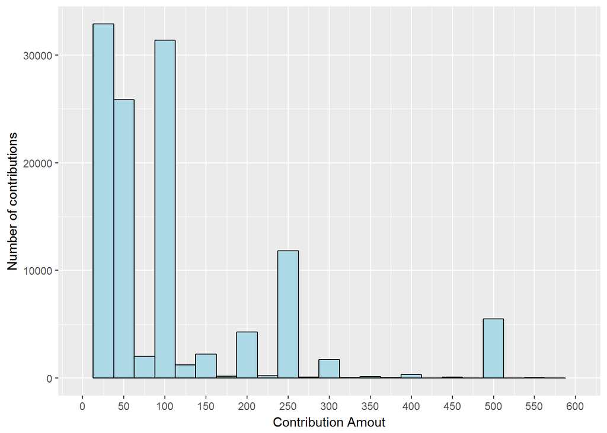

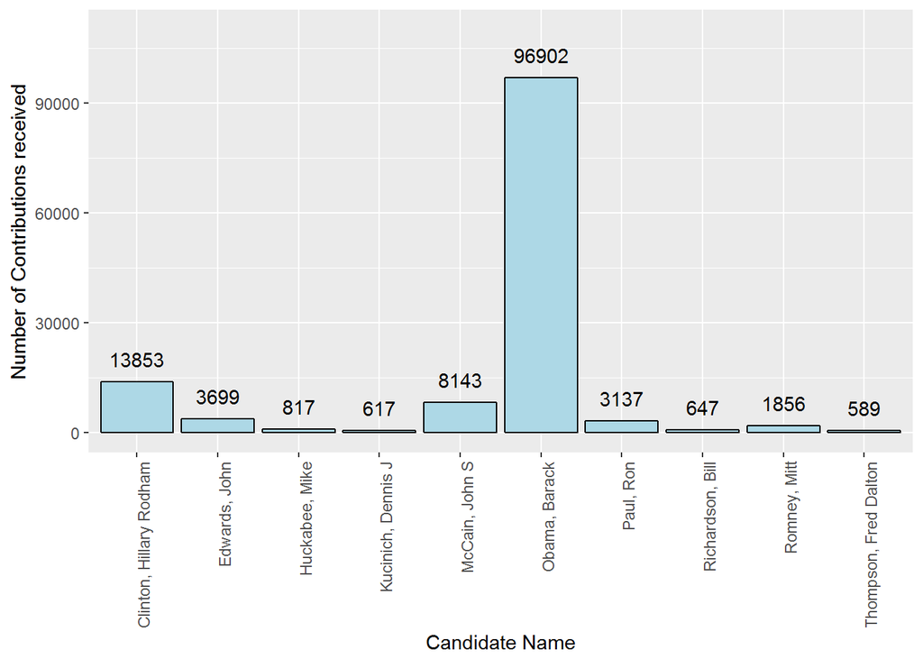

Above histogram shows that Barack Obama received significantly more number of contributions than any other candidate. Next highest number of contributions were received by Hillary Clinton.

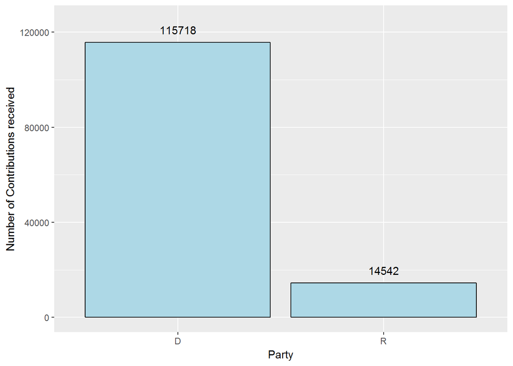

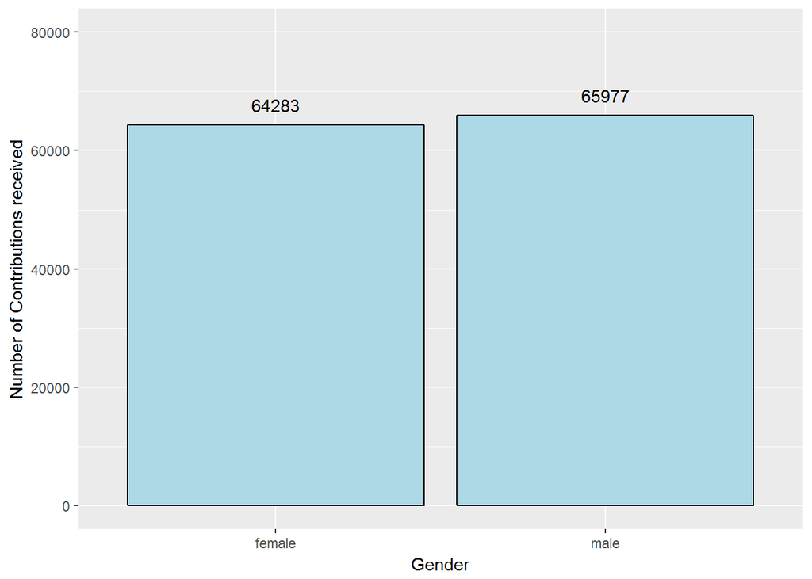

Number of Contributions from both males and females is almost equal

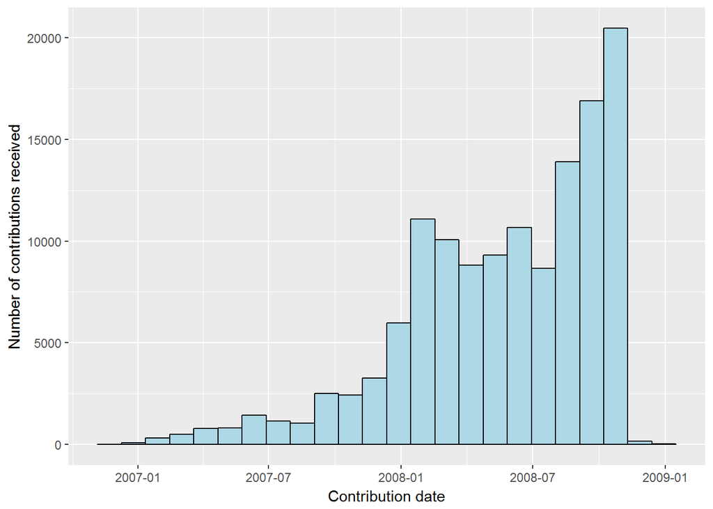

This is a negatively skewed distribution indicating most contributions came as the general election was getting close. In 2007 when candidates declared their intent to run, they started receiving contributions but in low numbers. Significant number of contributions came after primaries and national conventions are done.

# Univariate Analysis

### What is/are the main feature(s) of interest in your dataset?

Main features of interest for analysis is the size and number of contributions. Number of contributions received by party Number of contributions received by each candidate ### What other features in the dataset do you think will help support your investigation into your feature(s) of interest?

Zipcodes impact on contributions Gender impact on contributions ### Did you create any new variables from existing variables in the dataset?

I created two new variables in the dataset. party - Candidate name is used to identify party for each record. This will help to analyze contributions by party. gender - I split the contributor’s name into first name and last name. With the help of gender package and utilizing the first name, I predicted the contributor’s gender. This will help to analyze gender influence on the contributions and support for a candidate.

# Bivariate Analysis

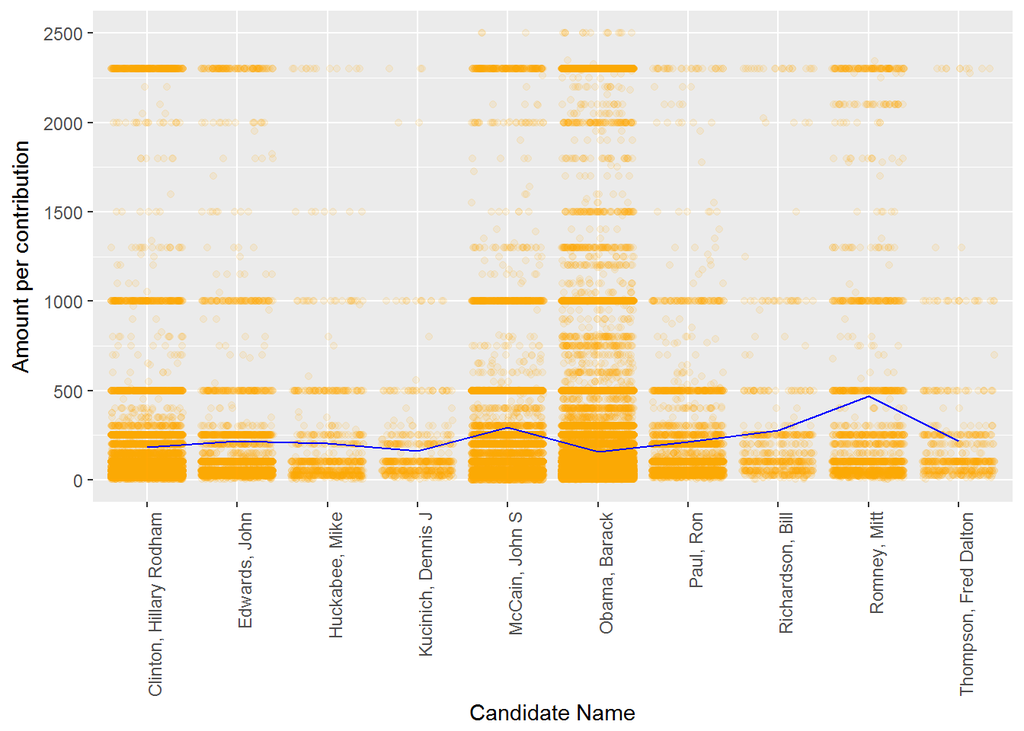

This scatter plot shows that most contributions are below $250. Also the line representing mean contributions by candidate shows John McCain and Mitt Romney (Republican candidates) have higher means than Hillary Clinton and Barack Obama(Democratic candidates).

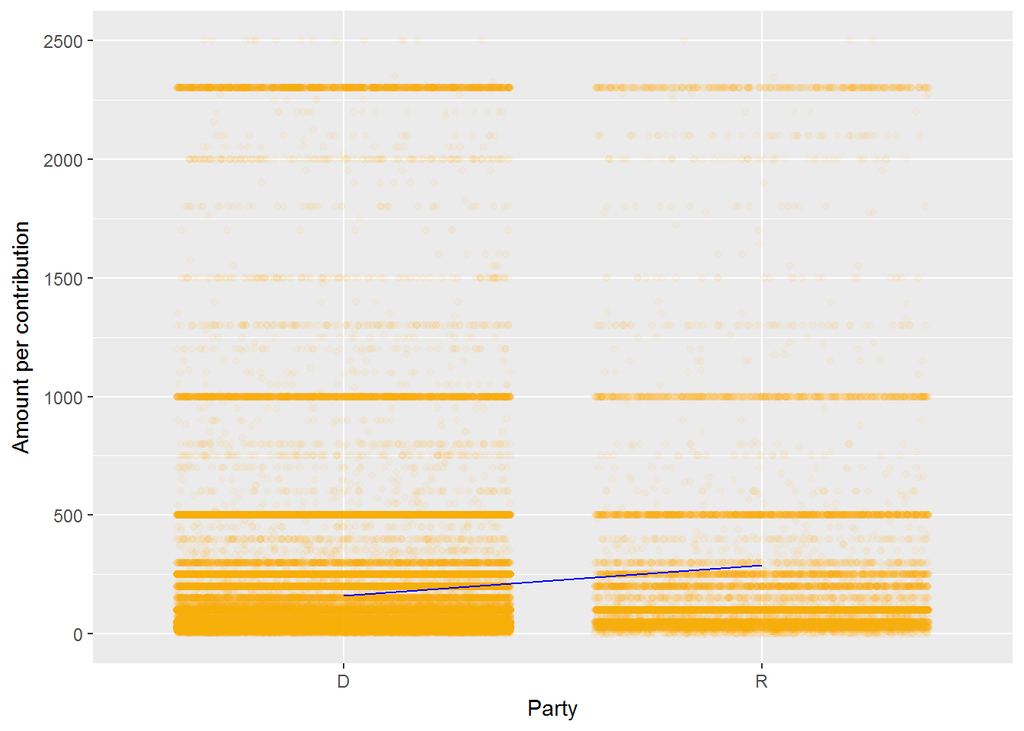

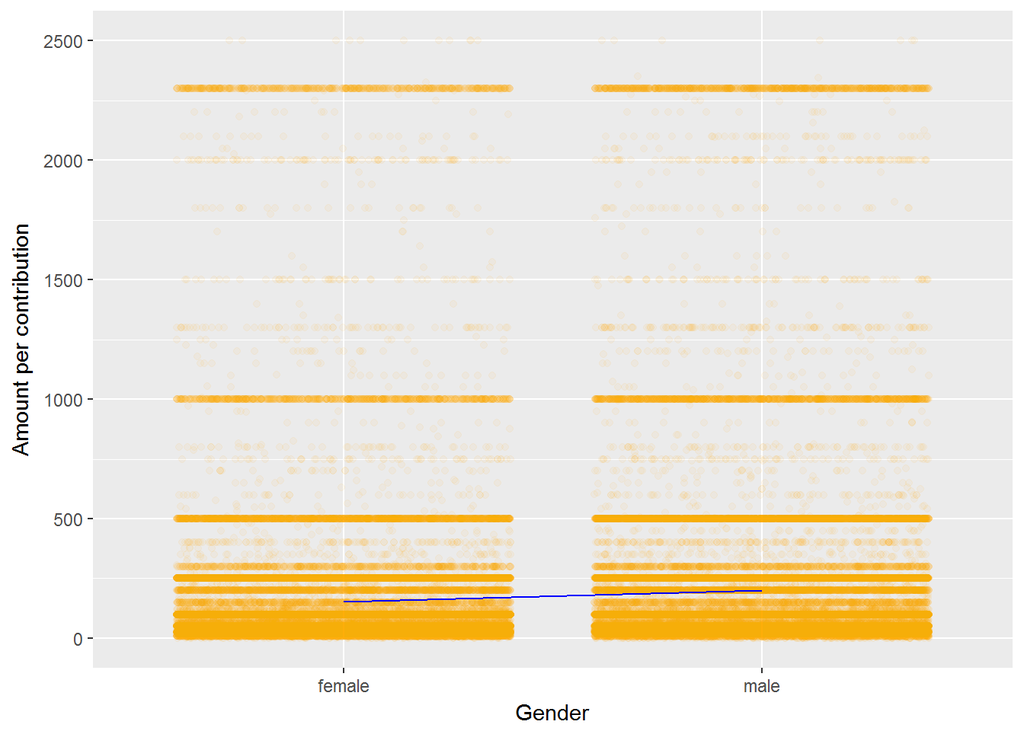

There is not a significant difference in number of contributions based on gender.

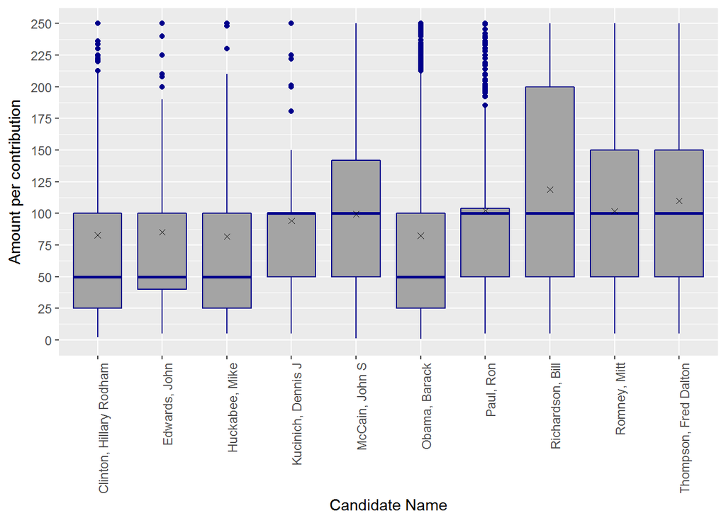

For most candidates their mean contribution received is higher than the mode.

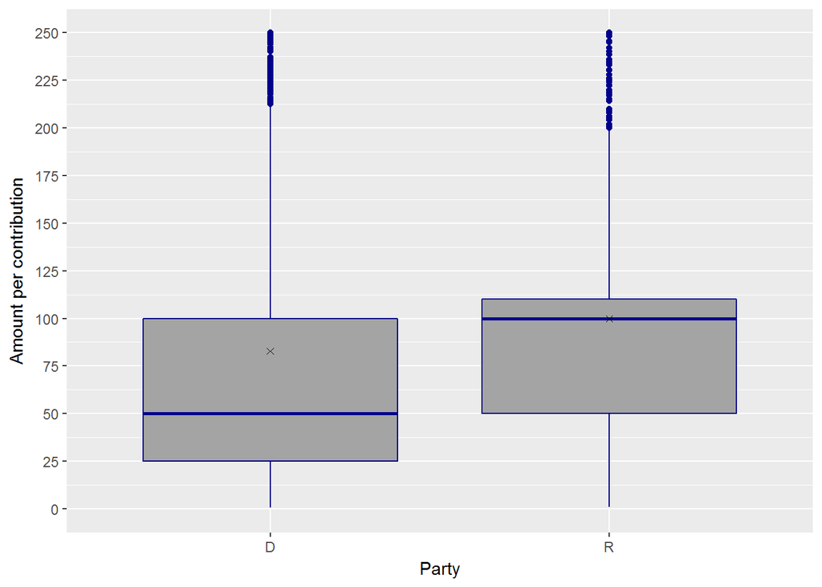

Both median and mean are higher for Republican party for the amount per contribution. Here x indicates the mean. This shows that even though overall number of contributions are lower for Republican party, amounts per contribution are higher.

### Data transformation - summarize contributions by candidate

```
## # A tibble: 10 × 5
##                    cand_nm contribution_mean contribution_median
##                     <fctr>             <dbl>               <dbl>
## 1  Clinton, Hillary Rodham          181.2440                  70
## 2            Edwards, John          214.5149                  60
## 3           Huckabee, Mike          203.2482                 100
## 4       Kucinich, Dennis J          159.5501                 100
## 5           McCain, John S          292.0577                 100
## 6            Obama, Barack          155.6946                  60
## 7                Paul, Ron          214.1618                 100
## 8         Richardson, Bill          275.3464                 100
## 9             Romney, Mitt          469.1298                 150
## 10   Thompson, Fred Dalton          216.6112                 100
## # ... with 2 more variables: contribution_total <dbl>, n <int>
```

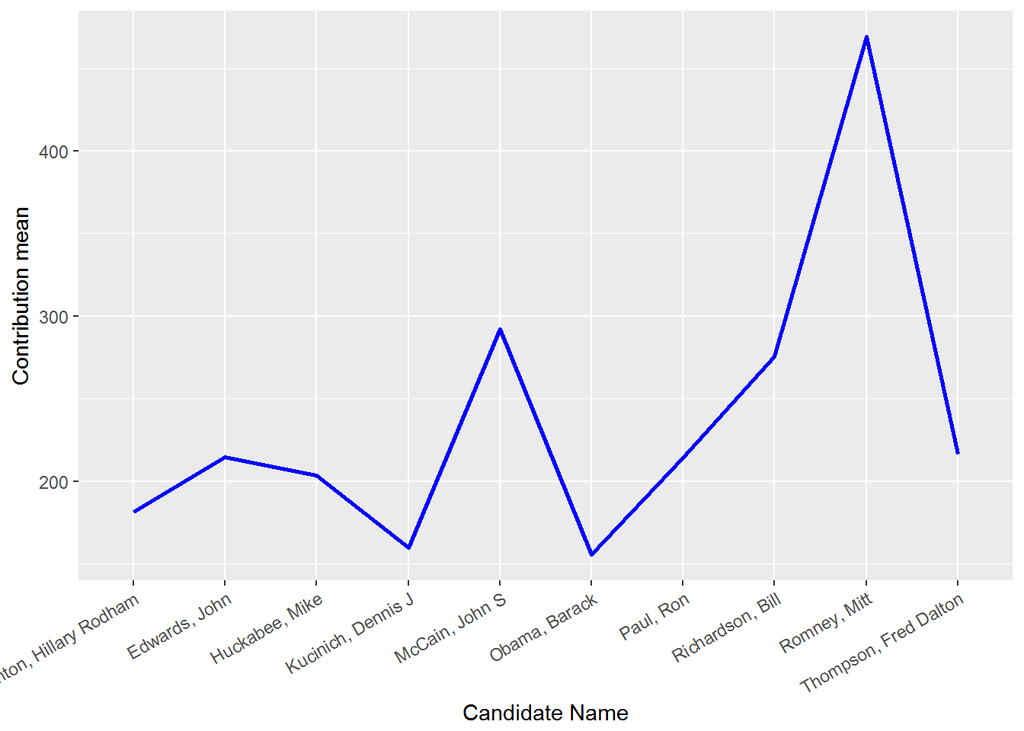

MItt Romney received the highest contribution means followed by John McCain.

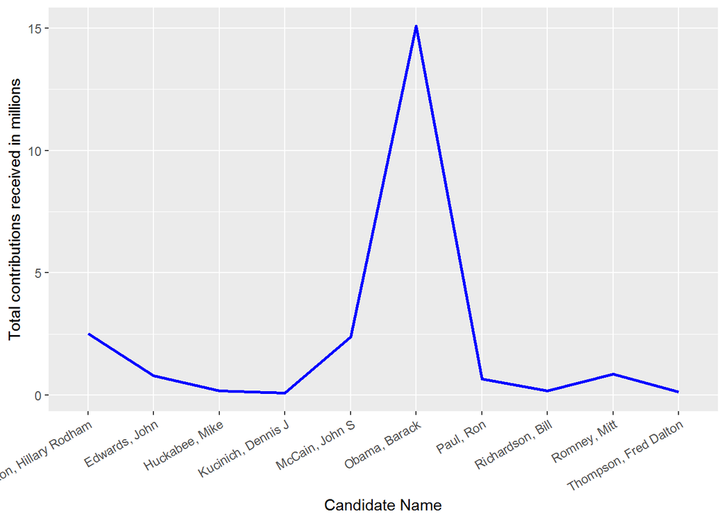

Overall Barack Obama received around $15 millions in total contributions even though his mean contributions are much lower than the republican candidates. Hillary Clinton received around $2.5 millions.

### create time series object with summarized monthly contributions

```
##                 [,1]
## 2006-11-22    1250.0
## 2006-12-29    4350.0
## 2007-01-31  137241.0
## 2007-02-28  154846.8
## 2007-03-31  647736.4
## 2007-04-30  189662.8
## 2007-05-31  320528.8
## 2007-06-30  892889.2
## 2007-07-31  168592.6
## 2007-08-31  261973.0
## 2007-09-30  650761.5
## 2007-10-31  650848.2
## 2007-11-30  544284.8
## 2007-12-31 1012440.2
## 2008-01-31 1450324.0
## 2008-02-29 2133297.8
## 2008-03-31 1238948.4
## 2008-04-30 1113223.9
## 2008-05-31  822944.3
## 2008-06-30 1341232.6
## 2008-07-31 1228731.9
## 2008-08-31 2095352.5
## 2008-09-30 3234318.6
## 2008-10-31 2296231.2
## 2008-11-28  276057.7
## 2008-12-30   14297.0
```

The above table shows contributions ($) received by month.

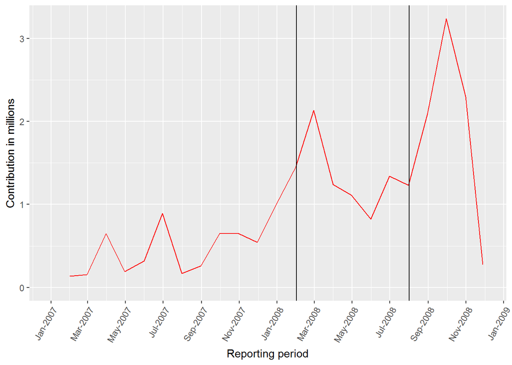

# Bivariate Analysis

### Talk about some of the relationships you observed in this part of the investigation. How did the feature(s) of interest vary with other features in the dataset?

Mean contribution amount for Republicans is higher compared to Democrats. This might be due to upper class leaning towards conservatives and middle class leaning towards liberals.

Both males and females equally participated in election contributions.

### Did you observe any interesting relationships between the other features?

Most of the contributions received were below $250.

The general election candidates, John McCain received total 8,143 contributions and Barack Obama received 96,902 which is almost 12 times more contributions than his Republican counterpart.

Contribution totals for Barack Obama is $15 million, where as John McCain received a total of $2.3 million.

### What was the strongest relationship you found?

Strongest relationship is between party and the number of contributions received. Since WA is liberal leaning state, it is no surprise there are significantly more number of contributions made to democrats than Republicans.

# Multivariate plots

### Summarize data by candidate name and contributor’s gender

```
## Source: local data frame [20 x 6]
## Groups: cand_nm [10]
##
##                    cand_nm gender contribution_mean contribution_median
##                     <fctr> <fctr>             <dbl>               <dbl>
## 1  Clinton, Hillary Rodham female          154.1804                  50
## 2  Clinton, Hillary Rodham   male          247.6982                 100
## 3            Edwards, John female          185.4137                  50
## 4            Edwards, John   male          245.5508                 100
## 5           Huckabee, Mike female          153.4650                  50
## 6           Huckabee, Mike   male          235.1375                 100
## 7       Kucinich, Dennis J female          147.9731                  75
## 8       Kucinich, Dennis J   male          169.3593                 100
## 9           McCain, John S female          280.2970                 100
## 10          McCain, John S   male          296.0483                 100
## 11           Obama, Barack female          138.7578                  50
## 12           Obama, Barack   male          172.3802                 100
## 13               Paul, Ron female          220.5909                 100
## 14               Paul, Ron   male          212.4224                 100
## 15        Richardson, Bill female          270.5209                 100
## 16        Richardson, Bill   male          279.9818                 100
## 17            Romney, Mitt female          453.1248                 100
## 18            Romney, Mitt   male          477.1001                 150
## 19   Thompson, Fred Dalton female          181.0230                 100
## 20   Thompson, Fred Dalton   male          231.5325                 100
## # ... with 2 more variables: contribution_total <dbl>, n <int>
```

```
##                    cand_nm     female      male
## 1  Clinton, Hillary Rodham 1517751.46  993021.9
## 2            Edwards, John  353954.79  439535.9
## 3           Huckabee, Mike   48955.32  117098.5
## 4       Kucinich, Dennis J   41876.39   56566.0
## 5           McCain, John S  578252.64 1799973.4
## 6            Obama, Barack 6672721.95 8414393.2
## 7                Paul, Ron  147354.75  524470.8
## 8         Richardson, Bill   85755.13   92394.0
## 9             Romney, Mitt  279578.00  591127.0
## 10   Thompson, Fred Dalton   31498.00   96086.0
```

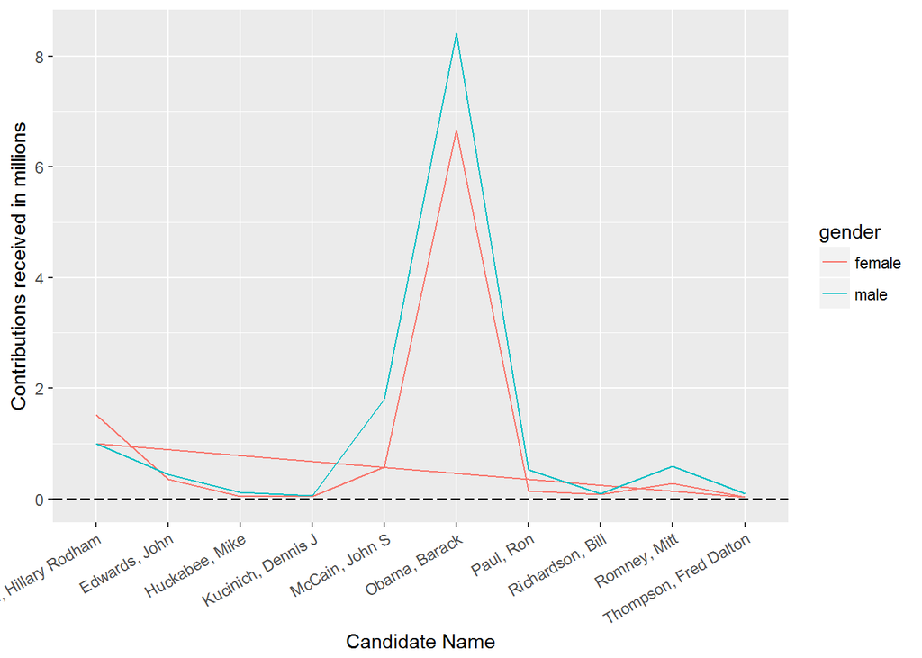

Out of the people contributed to each candidate, females outweigh males for Hillary and vice versa for Barack Obama.

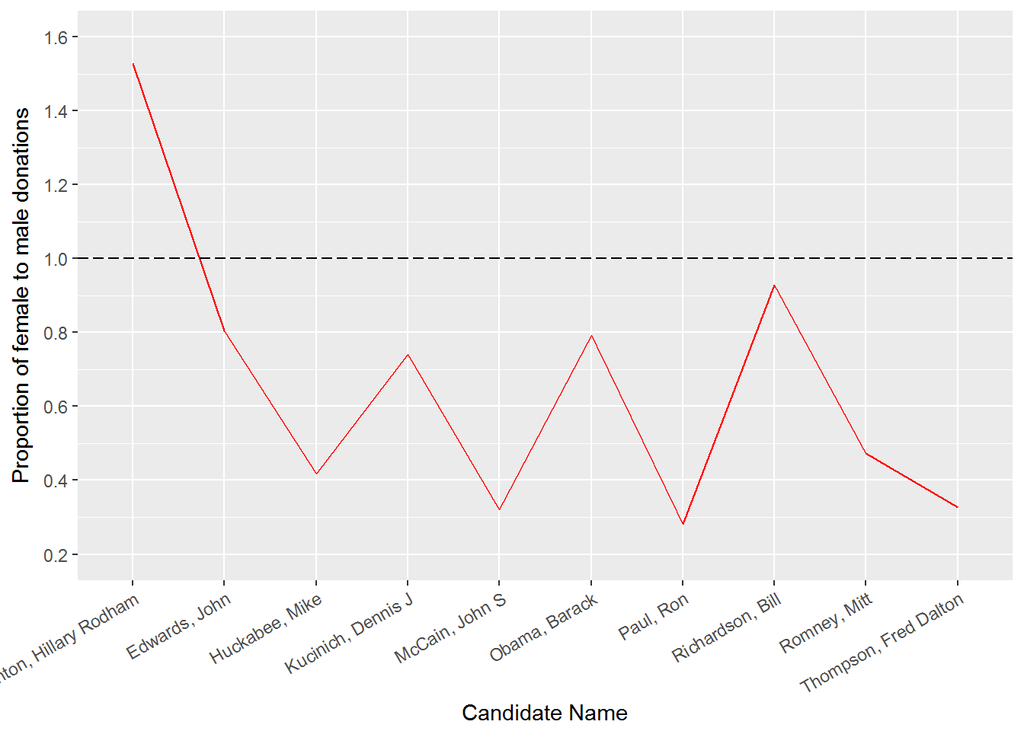

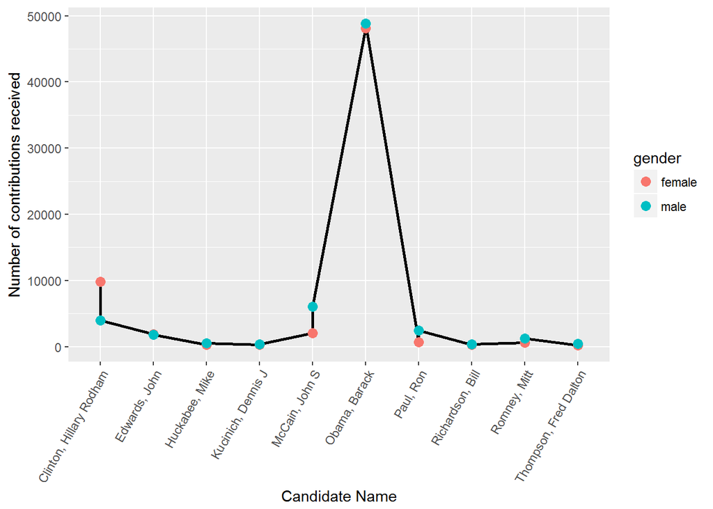

This line plot shows us number of contributions received from males vs females for each candidate. Hillary Clinton received more contributions from females compared to males.

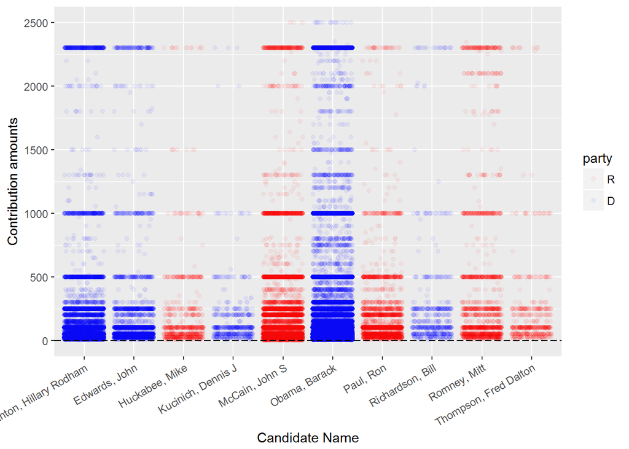

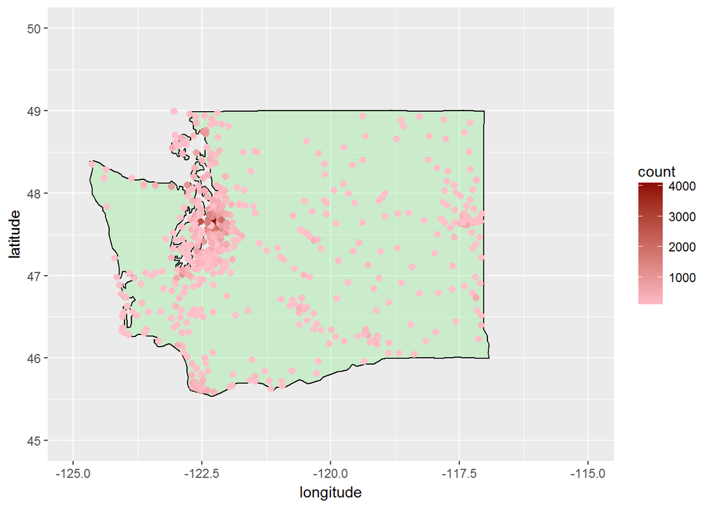

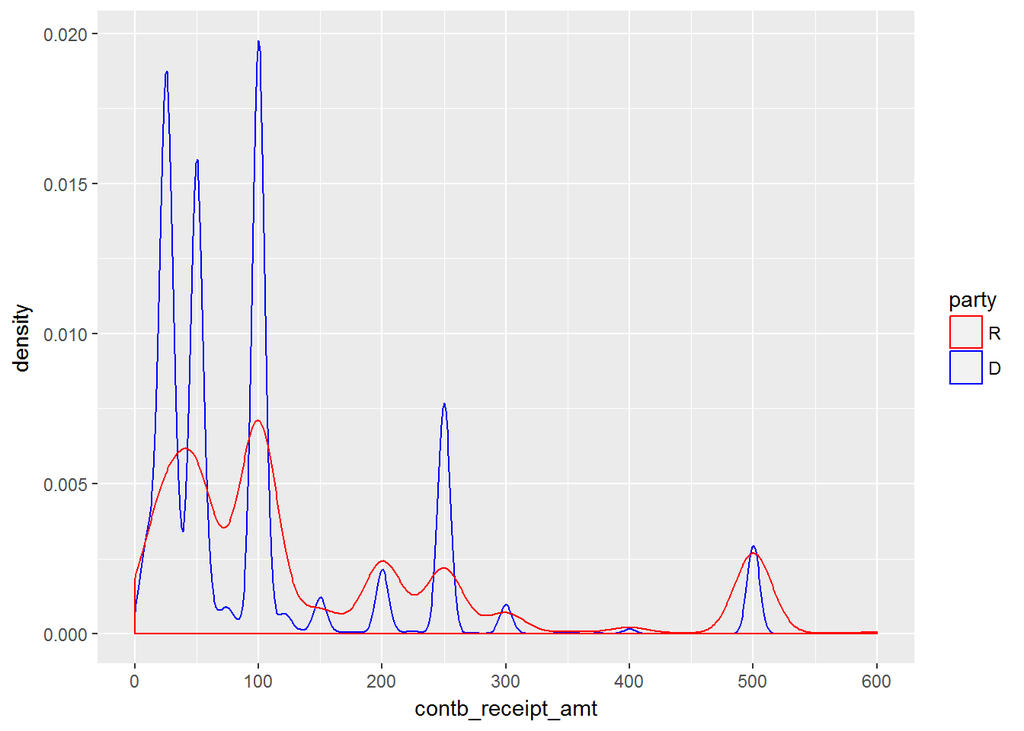

The density curve shows democrats have high probability of receiving modest contributions compared to Republicans.

### Create a linear regression model to predict contribution amounts

m1 = lm(contb_receipt_amt ~ cand_nm + gender + contbr_zip , data=wa) R-squared is 0.069 and it doesn’t seem to be a very strong model. Given that contribution amounts vary a lot, it is very hard to predict it using a simple linear model. This is the best linear model that is possible for this data.

# Multivariate Analysis

### Talk about some of the relationships you observed in this part of theinvestigation. Were there features that strengthened each other in terms of looking at your feature(s) of interest?

More females donated to Hillary Clinton than males, for all other candidates number of male contributions are higher than females.

Most contributions are for below $250

### Were there any interesting or surprising interactions between features?

More number contributions came from urban areas compared to rural areas.

### OPTIONAL: Did you create any models with your dataset? Discuss the strengths and limitations of your model.

Created a linear model to predict the contribution amounts. However it is a very weak model with R-square value of 0.069. Given that contribution amounts vary a lot, it is hard to predict it using a linear model.

# Final Plots and Summary

### Plot One

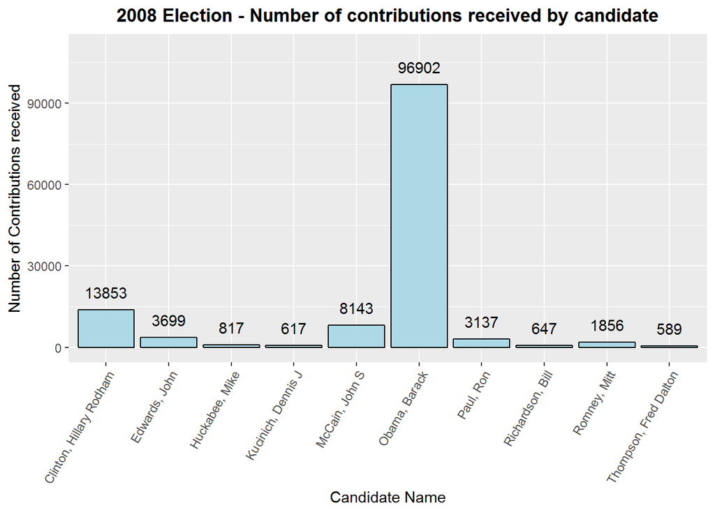

### Description One

This plot shows the energy and passion people had for Barack Obama and it reflected in the overwhelming number of contributions he received compared to other candidates.

### Plot Two

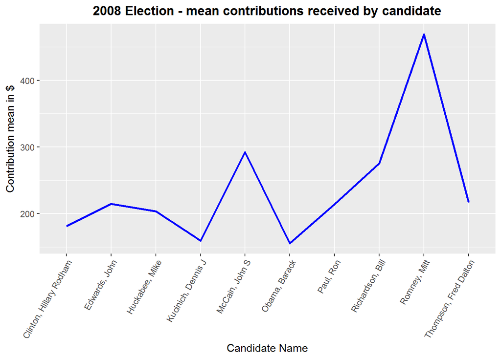

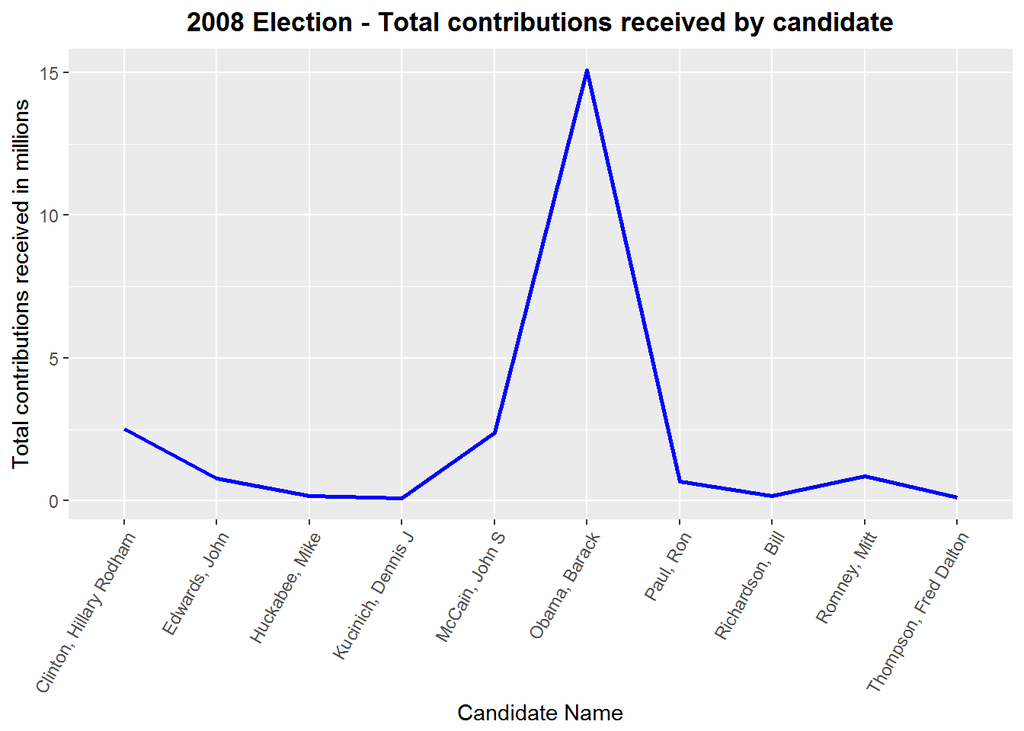

### Plot Three

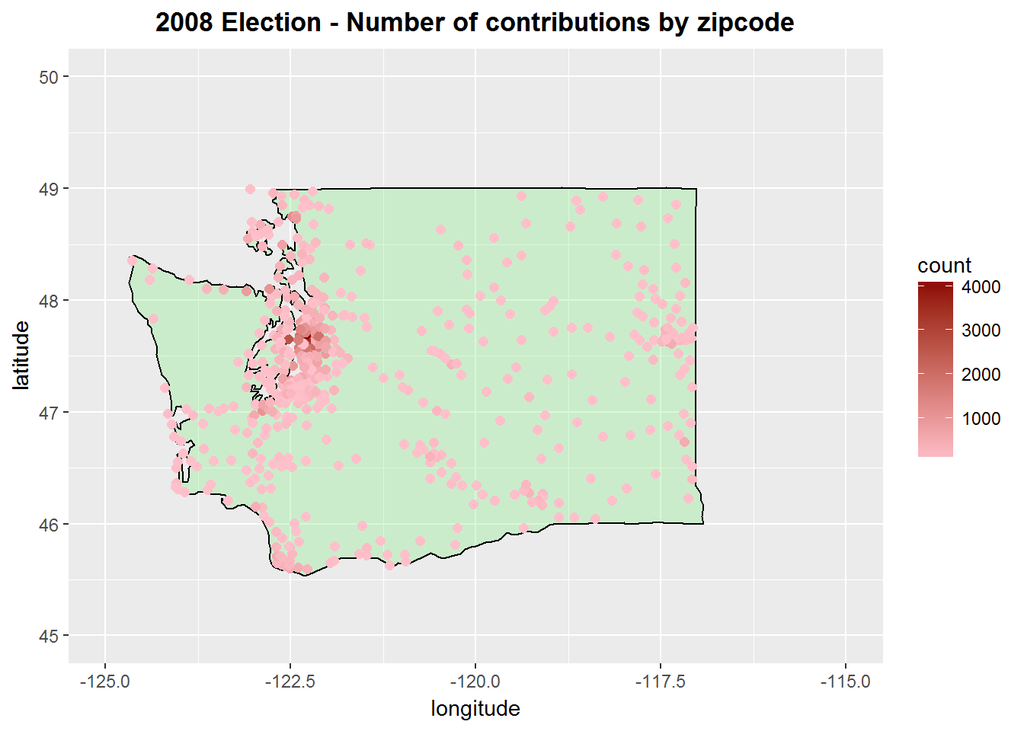

# Reflection

I created a linear model to predict contribution amounts based on the variables gender, zipcode and candidate name. It turned out that it is a weak model with R-squared 0.069. I expected adding Party will improve the model, but didn’t make a difference. Given that contribution amounts vary a lot, it will be very hard to predict it with a simple linear model. A different type of model should be considered in the future. Further analysis can be done based on contributor’s occupation, but the data will need lot of clean up before analysis.